# Explicit MPC for hybrid systems

Model predictive control (MPC) is not computationally cheap (compared to, say, PID or LQG control) as it requires solving optimization problem – typically a quadratic program (QP) - online. The optimization solver needs to be a part of the controller.

There is an alternative, though, at least in same cases. It is called *explicit MPC*. The computationally heavy optimization is only perfomed only during the design process and the MPC controller is then implemented just as an affine state feedback

$$\bm u_k(\bm x(k)) = \mathbf F_k^i \bm x(k) + \mathbf g_k^i,\; \text{if}\; \bm x(k) \in \mathcal R_k^i,$$

with the coefficients picked from some kind of a lookup table in real time Although retreiving the coefficients of the feedback controller is not computationally trivial, still it is cheaper than full optimization.

## Multiparametric programming

The key technique for explicit MPC is multi-parametric programming. In order to explain it, consider the following problem

$$J^\star(x) = \inf_z J(z;x).$$

The $z$ variable is an optimization variable, while $x$ is a parameter. For a given parameter $x$, the cost function $J$ is minimized. We study how the optimal cost $J^\star$ depends on the parameter, hence the name *parametric programming*. If $x$ is a vector, the name of the problem changes to *multiparametric programming*.

### Example: scalar variable, single parameter

Consider the following cost function $J(z;x)$ in $z$ parameterized by $x$. The optimization variable $z$ is constrained and this constraint is also parameterized by $x$.
$$\begin{aligned}
J(z;x) &= \frac{1}{2} z^2 + 2zx + 2x^2 \\
\text{subject to} &\quad z \leq 1 + x.
\end{aligned}$$

In this simple case we can aim at analytical solution. We proceed in the standard way – we introduce a Lagrange multiplicator $\lambda$ and form the augmented cost function
$$L(z,\lambda; x) = \frac{1}{2} z^2 + 2zx + 2x^2 + \lambda (z-1-x).$$

The necessary conditions of optimality for the inequality-constrained problem come in the form of KKT conditions
$$\begin{aligned}
z + 2x + \lambda &= 0,\\
z - 1 - x &\leq 0,\\
\lambda & \geq 0,\\
\lambda (z - 1 - x) &= 0.
\end{aligned}$$

The last condition – the complementarity condition – gives rise to two scenarios: one corresponding to $\lambda = 0$, and the other corresponding to $z - 1 - x = 0$. We consider them separately below.

After substituting $\lambda = 0$ into the KKT conditions, we get
$$\begin{aligned}
z + 2x &= 0,\\
z - 1 - x & \leq 0.
\end{aligned}$$

From the first equation we get how $z$ depends on $x$, and from the second we obtain a bound on $x$. Finally, we can also substitute the expression for $z$ into the cost function $J$ to get the optimal cost $J^\star$ as a function of $x$. All these are summarized here
$$\begin{aligned}
z^\star &= -2x,\\
x & \geq -\frac{1}{3},\\
J^\star(x) &= 0.
\end{aligned}$$

Now, the other scenario. Upon substitutin $z - 1 - x = 0$ into the KKT conditions we get

$$\begin{aligned}
z + 2x + \lambda &= 0,\\
z - 1 - x &= 0,\\
\lambda & \geq 0.
\end{aligned}$$

From the second equation we get the expression for $z$ in terms of $x$, substituting into the first equation and invoking the condition on nonnegativity of $\lambda$ we get the bound on $x$ (not surprisingly it complements the one obtained in the previous scenario). Finally, substituting for $z$ in the cost function $J$ we get a formula for the cost $J^\star$ as a function of $x$.

$$\begin{aligned}
z^\star &= 1 + x,\\
\lambda &= -z^\star - 2x \geq 0 \quad \implies \quad x \leq -\frac{1}{3},\\
J^\star(x) &= \frac{9}{2}x^2 + 3x + \frac{1}{2}.
\end{aligned}$$

The two scenarios can now be combined into a single piecewise affine function $z^\star(x)$
$$z^\star(x) = \begin{cases}
1+x & \text{if } x \leq -\frac{1}{3},\\
-2x & \text{if } x > -\frac{1}{3}.
\end{cases}$$

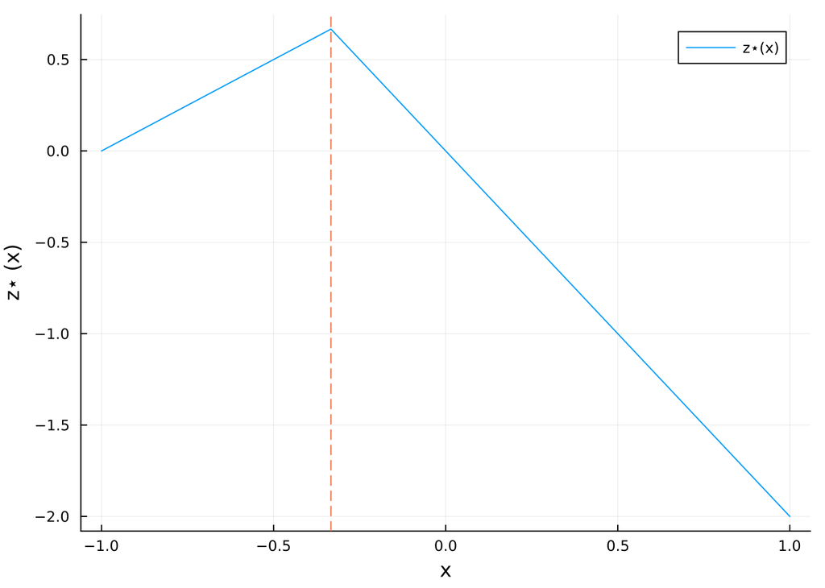

```julia
x = range(-1, 1, length=100)
z(x) = x <= -1/3 ? 1 + x : -2x
Jstar(x) = x <= -1/3 ? 9/2*x^2 + 3x + 1/2 : 0

using Plots
plot(x, z.(x), label="z⋆(x)")
vline!([-1/3],line=:dash, label="")
xlabel!("x")
ylabel!("z⋆ (x)")
```

and a piecewise quadratic cost function $J^\star(x)$
$$J^\star(x) = \begin{cases}
\frac{9}{2}x^2 + 3x + \frac{1}{2} & \text{if } x \leq -\frac{1}{3},\\
0 & \text{if } x > -\frac{1}{3}.
\end{cases}$$

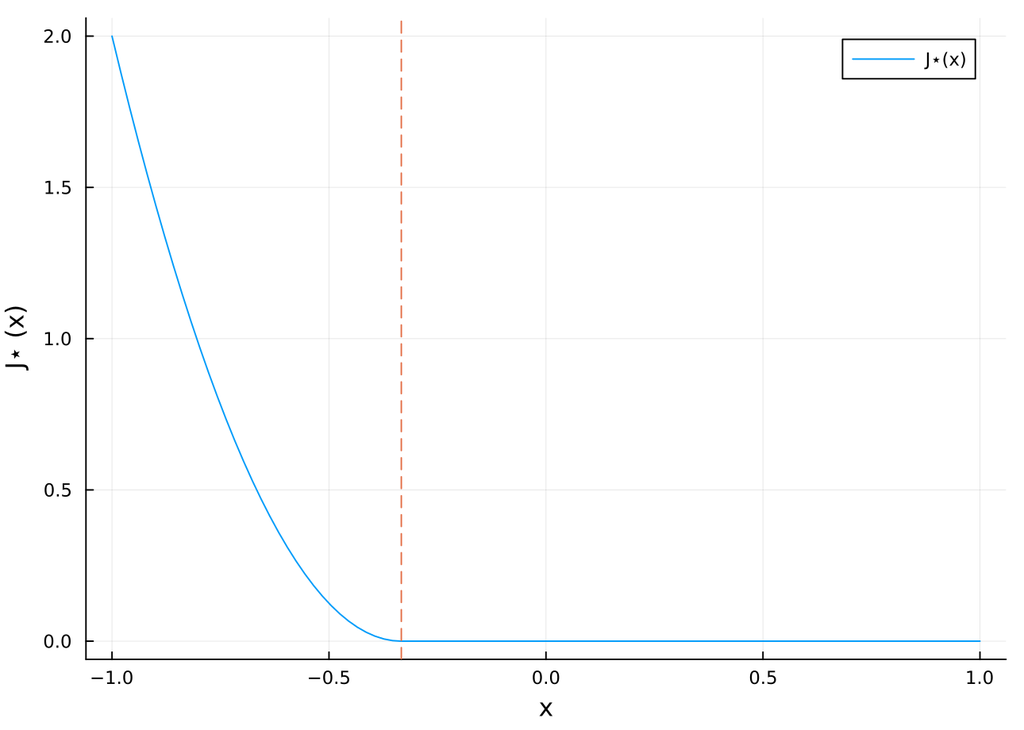

```julia
plot(x, Jstar.(x), label="J⋆(x)")
vline!([-1/3],line=:dash, label="")
xlabel!("x")
ylabel!("J⋆ (x)")
```